# linear_models_experiments

**Сергеенкова Лилия**

**Вывод формулы градиента функции потерь:**

$L(a(x), y) = \ln(1+e^{-ya(x)})$, где $a(x)= <x, w>$

$dL(a(x), y) = d(\ln(1+e^{-ya(x)})) = \frac{d(1+e^{-y<w,x>})}{1+e^{-y<w,x>}}=\frac{e^{-y<w,x>}d(-y<w,x>)}{1+e^{-y<w,x>}} =\frac{e^{-y<w,x>}(-y)<x,dw>)}{1+e^{-y<w,x>}} = \frac{(-y)<x,dw>}{1+e^{y<w,x>}} = <-y\sigma(-ya(x))x, dw>$

Таким образом, $\nabla L_w = -y\sigma(-ya(x))x$

```python
from modules.losses import BaseLoss, BinaryLogisticLoss
from modules.linear_model import LinearModel
```

```python
import pandas as pd
```

```python
data_train = pd.read_csv('toxic_train_test_data/train.csv')
data_train
```

|  | comment_text | is_toxic | toxic_level | insult | obscene | obscene_and_insult | no_obscene_no_insult |
| --- | --- | --- | --- | --- | --- | --- | --- |
| 0 | Explanation\nWhy the edits made under my usern... | 0 | 0 | 0 | 0 | 0 | 0 |
| 1 | D'aww! He matches this background colour I'm s... | 0 | 0 | 0 | 0 | 0 | 0 |
| 2 | Hey man, I'm really not trying to edit war. It... | 0 | 0 | 0 | 0 | 0 | 0 |
| 3 | "\nMore\nI can't make any real suggestions on ... | 0 | 0 | 0 | 0 | 0 | 0 |
| 4 | You, sir, are my hero. Any chance you remember... | 0 | 0 | 0 | 0 | 0 | 0 |
| ... | ... | ... | ... | ... | ... | ... | ... |
| 159566 | ":::::And for the second time of asking, when ... | 0 | 0 | 0 | 0 | 0 | 0 |
| 159567 | You should be ashamed of yourself \n\nThat is ... | 0 | 0 | 0 | 0 | 0 | 0 |
| 159568 | Spitzer \n\nUmm, theres no actual article for ... | 0 | 0 | 0 | 0 | 0 | 0 |
| 159569 | And it looks like it was actually you who put ... | 0 | 0 | 0 | 0 | 0 | 0 |
| 159570 | "\nAnd ... I really don't think you understand... | 0 | 0 | 0 | 0 | 0 | 0 |

159571 rows × 7 columns

```python
data_test = pd.read_csv('toxic_train_test_data/test.csv')
data_test.head()
```

|  | comment_text | is_toxic | toxic_level | insult | obscene | obscene_and_insult | no_obscene_no_insult |
| --- | --- | --- | --- | --- | --- | --- | --- |
| 0 | Thank you for understanding. I think very high... | 0 | 0 | 0 | 0 | 0 | 0 |
| 1 | :Dear god this site is horrible. | 0 | 0 | 0 | 0 | 0 | 0 |
| 2 | "::: Somebody will invariably try to add Relig... | 0 | 0 | 0 | 0 | 0 | 0 |
| 3 | " \n\n It says it right there that it IS a typ... | 0 | 0 | 0 | 0 | 0 | 0 |
| 4 | " \n\n == Before adding a new product to the l... | 0 | 0 | 0 | 0 | 0 | 0 |

**Задание №1**

```python
import re
from nltk.stem.wordnet import WordNetLemmatizer

class Preprocesser:
    def __init__(self, stopwords):
        self.bad_symbol_regexp = re.compile('[^a-zA-Z0-9\s]')
        ru_lemmatizer = WordNetLemmatizer()
        def lru_lemmatizer(word):
            return ru_lemmatizer.lemmatize(word)
        self.lemmatizer = lru_lemmatizer
        self.stopwords = stopwords

    def __call__(self, text):
        text = text.lower()
        text = re.sub(self.bad_symbol_regexp, '', text)
        lemmas = [
            self.lemmatizer(token)
            for token in text.split()
        ]
        lemmas = [
            token
            for token in lemmas
            if token not in self.stopwords
        ]

        return ' '.join(lemmas)
```

```python
# предобработка

from nltk.corpus import stopwords
stopwords = set(stopwords.words('english'))
preprocess_text = Preprocesser(stopwords=stopwords)
```

```python
data_train['comment_text'] = data_train['comment_text'].apply(preprocess_text)
```

```python
data_test['comment_text'] = data_test['comment_text'].apply(preprocess_text)
```

```python
data_train
```

|  | comment_text | is_toxic | toxic_level | insult | obscene | obscene_and_insult | no_obscene_no_insult |
| --- | --- | --- | --- | --- | --- | --- | --- |
| 0 | explanation edits made username hardcore metal... | 0 | 0 | 0 | 0 | 0 | 0 |
| 1 | daww match background colour im seemingly stuc... | 0 | 0 | 0 | 0 | 0 | 0 |
| 2 | hey man im really trying edit war guy constant... | 0 | 0 | 0 | 0 | 0 | 0 |
| 3 | cant make real suggestion improvement wondered... | 0 | 0 | 0 | 0 | 0 | 0 |
| 4 | sir hero chance remember page thats | 0 | 0 | 0 | 0 | 0 | 0 |
| ... | ... | ... | ... | ... | ... | ... | ... |
| 159566 | second time asking view completely contradicts... | 0 | 0 | 0 | 0 | 0 | 0 |
| 159567 | ashamed horrible thing put talk page 128611993 | 0 | 0 | 0 | 0 | 0 | 0 |
| 159568 | spitzer umm actual article prostitution ring c... | 0 | 0 | 0 | 0 | 0 | 0 |
| 159569 | look like wa actually put speedy first version... | 0 | 0 | 0 | 0 | 0 | 0 |
| 159570 | really dont think understand came idea wa bad ... | 0 | 0 | 0 | 0 | 0 | 0 |

159571 rows × 7 columns

**Задание №2**

```python
# формируем тренировочную и валидационную выборки

from sklearn.model_selection import train_test_split

data_train_, data_val = train_test_split(data_train, test_size=0.3)
```

**Задание №3**

```python
from sklearn.feature_extraction.text import TfidfVectorizer
from scipy.sparse import hstack, csr_matrix
import numpy as np

vectorizer = TfidfVectorizer(min_df=5)

X = dict()
X['train'] = vectorizer.fit_transform(data_train_['comment_text'])

X['valid'] = vectorizer.transform(data_val['comment_text'])
X['test'] = vectorizer.transform(data_test['comment_text'])

for data_type in ['train', 'valid', 'test']:
    X[data_type] = csr_matrix(hstack([csr_matrix(np.ones((X[data_type].shape[0], 1))), X[data_type]]))
```

```python
y_train = np.asarray(data_train_['is_toxic'])
y_val = np.asarray(data_val['is_toxic'])
y_test = np.asarray(data_test['is_toxic'])

# приводим метки
y_train = 2*y_train - 1
y_val = 2*y_val - 1
y_test = 2*y_test - 1
```

**Задание №4**

```python
# исследование поведения в зависимости от step_alpha

from sklearn.metrics import balanced_accuracy_score, accuracy_score

loss_function = BinaryLogisticLoss(l2_coef=1.0)

results_alpha = []
ac_alpha = []

alpha_ = [0.01, 0.05, 0.1, 0.3, 0.5, 0.7, 0.9, 1.0]

for step_alpha in alpha_:
    model = LinearModel(loss_function=loss_function, step_alpha=step_alpha)
    history = model.fit(X=X['train'], y=y_train, trace=True, X_val=X['valid'], y_val=y_val)
    results_alpha.append(history)

    threshold = model.get_optimal_threshold(X['valid'], y_val)
    y_pred = model.predict(X['valid'], threshold)
    accu = balanced_accuracy_score(y_val, y_pred)
    ac_alpha.append(accu)
```

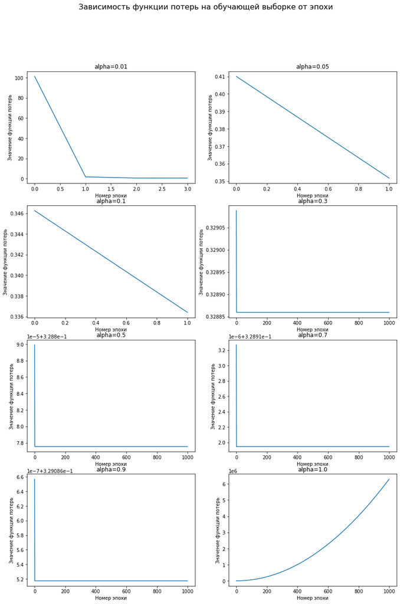

```python
# зависимость функции потерь на обучающей выборке от эпохи

import matplotlib.pyplot as plt

fig, ax = plt.subplots(nrows=4, ncols=2, figsize=(14, 20))
fig.suptitle('Зависимость функции потерь на обучающей выборке от эпохи', fontsize=16)
i=0
for row in ax:
    for col in row:
        col.plot(np.arange(len(results_alpha[i]['func'])), results_alpha[i]['func'])
        col.set_title('alpha=%s'%round(alpha_[i], 2))
        col.set_xlabel('Номер эпохи')
        col.set_ylabel('Значение функции потерь')
        i+=1

plt.subplots_adjust()

plt.show()
```

Как видно из графиков, значение функции потерь стремится к константе, ближе всего к нулю, при $\alpha=0.3$, при $\alpha=0.01,0.05,0.1$ метод очень быстро сходится(за несколько итераций), а при $\alpha=1.0$ расходится из-за большого значения шага.

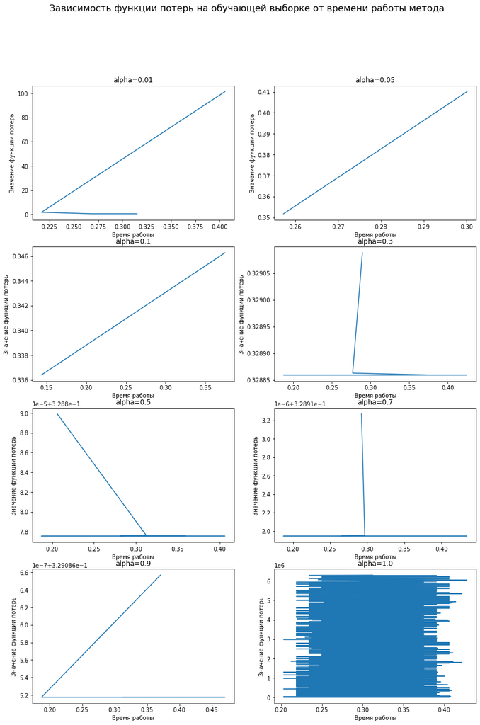

```python
# зависимость функции потерь на обучающей выборке от времени

fig, ax = plt.subplots(nrows=4, ncols=2, figsize=(14, 20))
fig.suptitle('Зависимость функции потерь на обучающей выборке от времени работы метода', fontsize=16)
i=0
for row in ax:
    for col in row:
        col.plot(results_alpha[i]['time'], results_alpha[i]['func'])
        col.set_title('alpha=%s'%round(alpha_[i], 2))
        col.set_xlabel('Время работы')
        col.set_ylabel('Значение функции потерь')
        i+=1

plt.subplots_adjust()

plt.show()
```

При снижении функции потерь к нулю требуется все больше итераций, при $\alpha=1.0$ наблюдается очень много скачков ввиду того, что метод расходится, при остальных значениях $\alpha$ функция потерь довольно быстро сходится к значению, близкому к нулю.

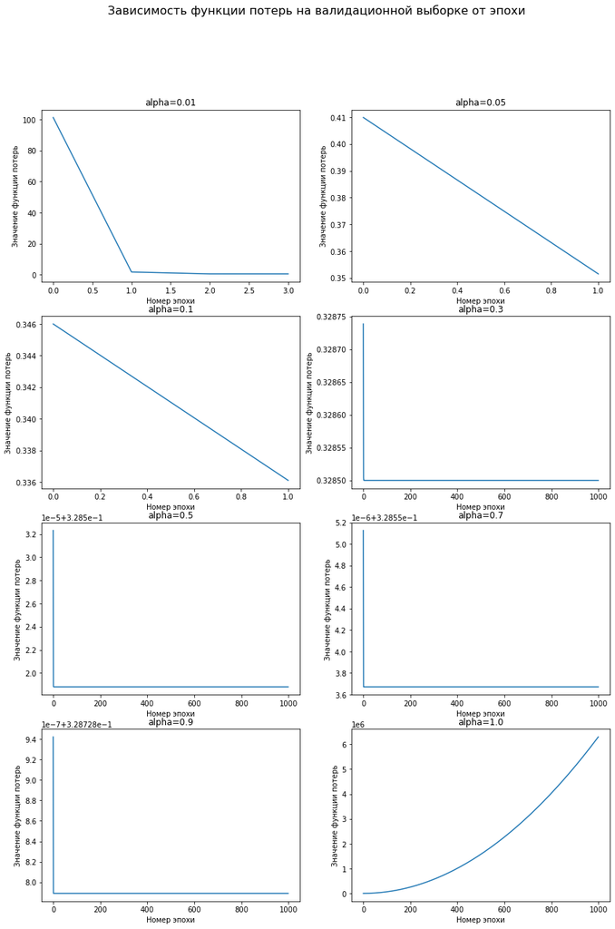

```python
# зависимость функции потерь на валидационной выборке от эпохи

import matplotlib.pyplot as plt

fig, ax = plt.subplots(nrows=4, ncols=2, figsize=(14, 20))
fig.suptitle('Зависимость функции потерь на валидационной выборке от эпохи', fontsize=16)
i=0
for row in ax:
    for col in row:
        col.plot(np.arange(len(results_alpha[i]['func_val'])), results_alpha[i]['func_val'])
        col.set_title('alpha=%s'%round(alpha_[i], 2))
        col.set_xlabel('Номер эпохи')
        col.set_ylabel('Значение функции потерь')
        i+=1

plt.subplots_adjust()

plt.show()
```

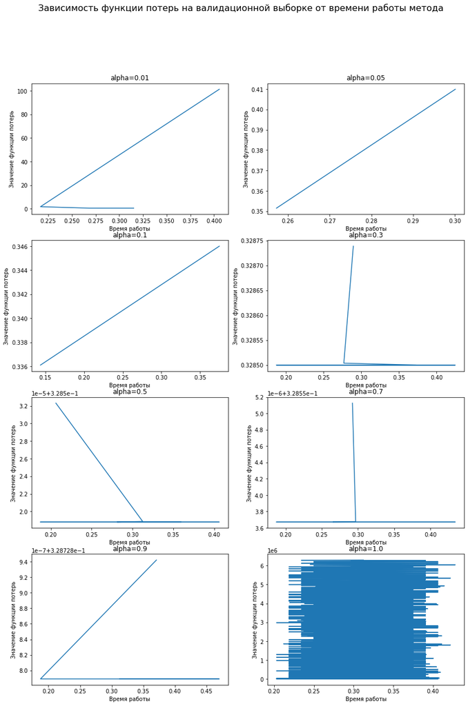

```python
# зависимость функции потерь на валидационной выборке от времени

import matplotlib.pyplot as plt

fig, ax = plt.subplots(nrows=4, ncols=2, figsize=(14, 20))
fig.suptitle('Зависимость функции потерь на валидационной выборке от времени работы метода', fontsize=16)
i=0
for row in ax:
    for col in row:
        col.plot(results_alpha[i]['time'], results_alpha[i]['func_val'])
        col.set_title('alpha=%s'%round(alpha_[i], 2))
        col.set_xlabel('Время работы')
        col.set_ylabel('Значение функции потерь')
        i+=1

plt.subplots_adjust()

plt.show()
```

Графики, полученные на валидационной выборке, аналогичны графикам на тренировочной, что означает что эти выборки схожи по своей структуре.

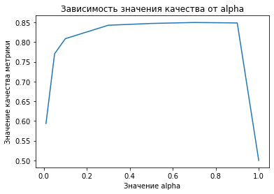

```python
# значения качества метрики

plt.plot(alpha_, ac_alpha)
plt.title('Зависимость значения качества от alpha')
plt.xlabel('Значение alpha')
plt.ylabel('Значение качества метрики')
plt.show()
```

Как видно из графика, при значениях параметра $\alpha$ от примерно 0.3 до 0.9 значение метрики находится на плато, более точное оптимальное значение рассчитано ниже.

```python
# исследование поведения в зависимости от step_beta

from sklearn.metrics import balanced_accuracy_score

loss_function = BinaryLogisticLoss(l2_coef=1.0)

results_beta = []
ac_beta = []

beta_ = np.arange(0, 1.01, 0.2)

for step_beta in beta_:
    model = LinearModel(loss_function=loss_function, step_beta=step_beta)
    history = model.fit(X=X['train'], y=y_train, trace=True, X_val=X['valid'], y_val=y_val)
    results_beta.append(history)

    threshold = model.get_optimal_threshold(X['valid'], y_val)
    y_pred = model.predict(X['valid'], threshold)
    ac_beta.append(balanced_accuracy_score(y_val, y_pred))
```

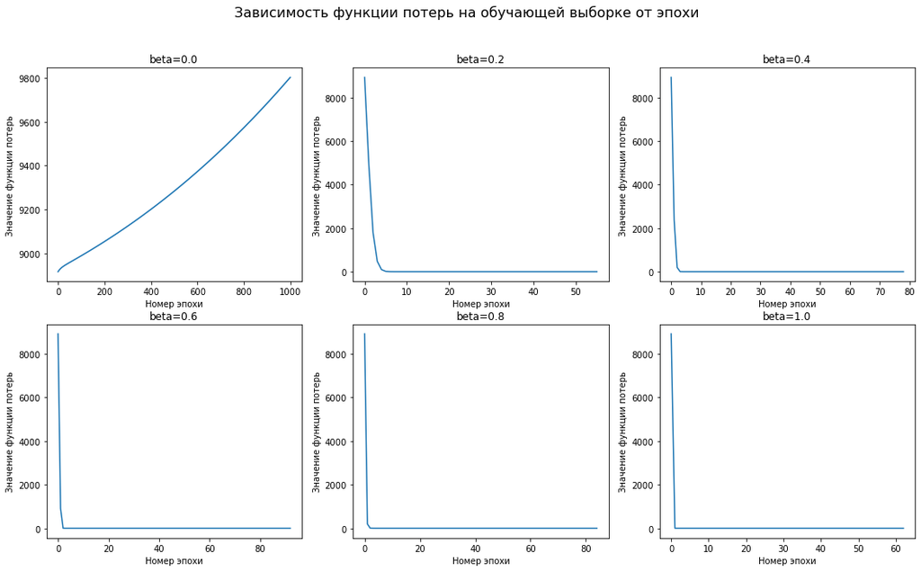

```python
# зависимость функции потерь на обучающей выборке от эпохи

import matplotlib.pyplot as plt


fig, ax = plt.subplots(nrows=2, ncols=int(len(results_beta)/2), figsize=(18, 10))
fig.suptitle('Зависимость функции потерь на обучающей выборке от эпохи', fontsize=16)
i=0
for row in ax:
    for col in row:
        col.plot(np.arange(len(results_beta[i]['func'])), results_beta[i]['func'])
        col.set_title('beta=%s'%round(beta_[i], 2))
        col.set_xlabel('Номер эпохи')
        col.set_ylabel('Значение функции потерь')
        i+=1

plt.subplots_adjust()

plt.show()
```

Как видно из графиков, при $\beta = 0$ наблюдается расходимость ввиду превращения знаменателя в единицу и отсутствия уменьшения шага, при остальных значениях функция потерь стремится к нулю.

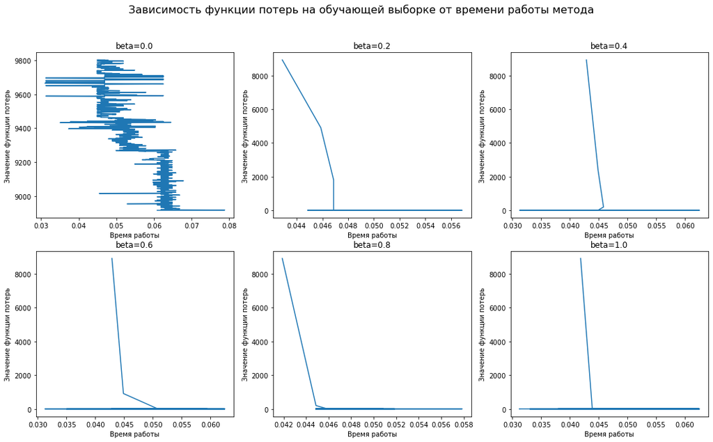

```python
# зависимость функции потерь на обучающей выборке от времени

fig, ax = plt.subplots(nrows=2, ncols=int(len(results_beta)/2), figsize=(18, 10))
fig.suptitle('Зависимость функции потерь на обучающей выборке от времени работы метода', fontsize=16)
i=0
for row in ax:
    for col in row:
        col.plot(results_beta[i]['time'], results_beta[i]['func'])
        col.set_title('beta=%s'%round(beta_[i], 2))
        col.set_xlabel('Время работы')
        col.set_ylabel('Значение функции потерь')
        i+=1

plt.subplots_adjust()

plt.show()
```

Как было сказано выше, при $\beta = 0$ наблюдается расходимость, так что на графике видно, что происходит много итераций, однако значение функции потерь значительно не уменьшается.

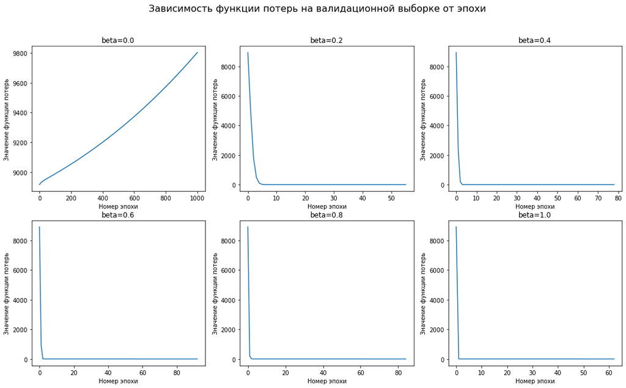

```python
# зависимость функции потерь на валидационной выборке от эпохи

import matplotlib.pyplot as plt

fig, ax = plt.subplots(nrows=2, ncols=int(len(results_beta)/2), figsize=(18, 10))
fig.suptitle('Зависимость функции потерь на валидационной выборке от эпохи', fontsize=16)
i=0
for row in ax:
    for col in row:
        col.plot(np.arange(len(results_beta[i]['func_val'])), results_beta[i]['func_val'])
        col.set_title('beta=%s'%round(beta_[i], 2))
        col.set_xlabel('Номер эпохи')
        col.set_ylabel('Значение функции потерь')
        i+=1

plt.subplots_adjust()

plt.show()
```

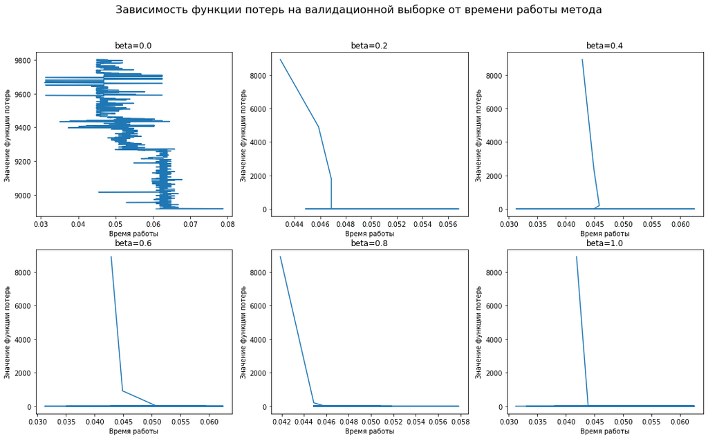

```python
# зависимость функции потерь на валидационной выборке от времени

import matplotlib.pyplot as plt

fig, ax = plt.subplots(nrows=2, ncols=int(len(results_beta)/2), figsize=(18, 10))
fig.suptitle('Зависимость функции потерь на валидационной выборке от времени работы метода', fontsize=16)
i=0
for row in ax:
    for col in row:
        col.plot(results_beta[i]['time'], results_beta[i]['func_val'])
        col.set_title('beta=%s'%round(beta_[i], 2))
        col.set_xlabel('Время работы')
        col.set_ylabel('Значение функции потерь')
        i+=1

plt.subplots_adjust()

plt.show()
```

Графики, полученные на валидационной выборке, аналогичны графикам на тренировочной, что означает что эти выборки схожи по своей структуре.

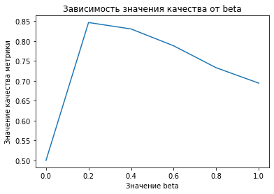

```python
# значения качества метрики

plt.plot(beta_, ac_beta)
plt.title('Зависимость значения качества от beta')
plt.xlabel('Значение beta')
plt.ylabel('Значение качества метрики')
plt.show()
```

```python
# оптимальные значения step_alpha и step_beta

max_ac_alpha = np.max(ac_alpha)
alpha_opt = list(ac_alpha).index(max_ac_alpha)
alpha_o = alpha_[alpha_opt]
print('Оптимальное значение alpha: ', alpha_o)

max_ac_beta = np.max(ac_beta)
beta_opt = list(ac_beta).index(max_ac_beta)
beta_o = beta_[beta_opt]
print('Оптимальное значение beta: ', beta_o)
```

```
Оптимальное значение alpha:  0.7
Оптимальное значение beta:  0.2
```

**Задание №5**

```python
X['train'].shape[0]
```

```
111699
```

```python
# исследование поведения стохастического градиента в зависимости от batch_size

loss_function = BinaryLogisticLoss(l2_coef=1.0)

results_batch_size = []
ac_batch_size = []

batch_size_ = [100, 1000, 5000, 10000, 50000, 100000]

for batch_size in batch_size_:
    model = LinearModel(loss_function=loss_function, batch_size=batch_size, step_alpha=alpha_o, step_beta=beta_o)
    history = model.fit(X=X['train'], y=y_train, trace=True, X_val=X['valid'], y_val=y_val)
    results_batch_size.append(history)
```

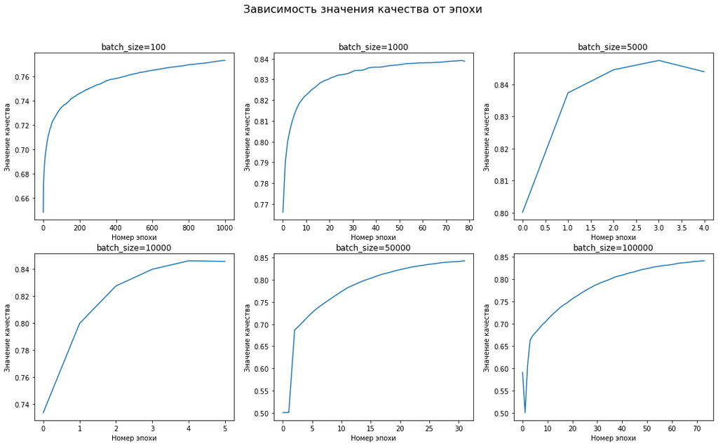

```python
# зависимость значения качества от эпохи при разных batch_size

import matplotlib.pyplot as plt

fig, ax = plt.subplots(nrows=2, ncols=int(len(results_batch_size)/2), figsize=(18, 10))
fig.suptitle('Зависимость значения качества от эпохи', fontsize=16)
i=0
for row in ax:
    for col in row:
        col.plot(np.arange(len(results_batch_size[i]['accuracy'])), results_batch_size[i]['accuracy'])
        col.set_title('batch_size=%s'%batch_size_[i])
        col.set_xlabel('Номер эпохи')
        col.set_ylabel('Значение качества')
        i+=1

plt.subplots_adjust()

plt.show()
```

Сходятся методы при разных значениях примерно к одному и тому же значению качества, но за разное число эпох: минимальное число потребовалось при размере 5000 и 10000, что гораздо лучше, чем в полном градиетном спуске, также небольшое количество эпох потребовалось и для остальных размеров, кроме 100. В этом и заключается преимущество стохастического градиента.

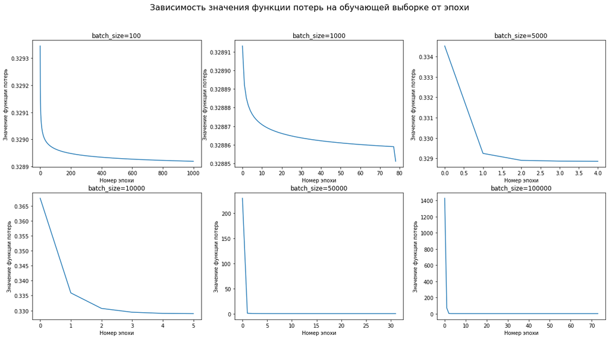

```python
# зависимость функции потерь на обучающей выборке от эпохи

import matplotlib.pyplot as plt

fig, ax = plt.subplots(nrows=2, ncols=int(len(results_batch_size)/2), figsize=(20, 10))
fig.suptitle('Зависимость значения функции потерь на обучающей выборке от эпохи', fontsize=16)
i=0
for row in ax:
    for col in row:
        col.plot(np.arange(len(results_batch_size[i]['func'])), results_batch_size[i]['func'])
        col.set_title('batch_size=%s'%batch_size_[i])
        col.set_xlabel('Номер эпохи')
        col.set_ylabel('Значение функции потерь')
        i+=1

plt.subplots_adjust()

plt.show()
```

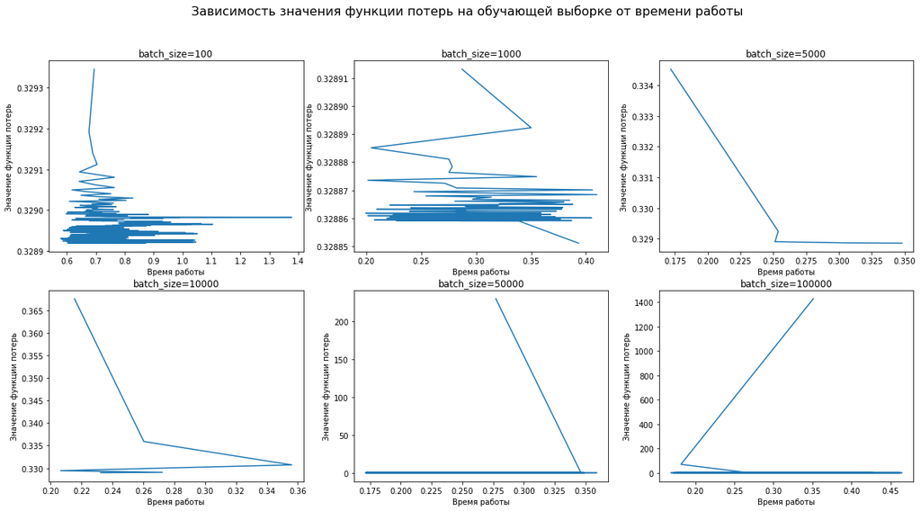

```python
# зависимость функции потерь на обучающей выборке от времени работы

import matplotlib.pyplot as plt

fig, ax = plt.subplots(nrows=2, ncols=int(len(results_batch_size)/2), figsize=(20, 10))
fig.suptitle('Зависимость значения функции потерь на обучающей выборке от времени работы', fontsize=16)
i=0
for row in ax:
    for col in row:
        col.plot(results_batch_size[i]['time'], results_batch_size[i]['func'])
        col.set_title('batch_size=%s'%batch_size_[i])
        col.set_xlabel('Время работы')
        col.set_ylabel('Значение функции потерь')
        i+=1

plt.subplots_adjust()

plt.show()
```

При значениях batch-a больше 5000 наблюдается быстрое снижение функции потерь за малое количество эпох.

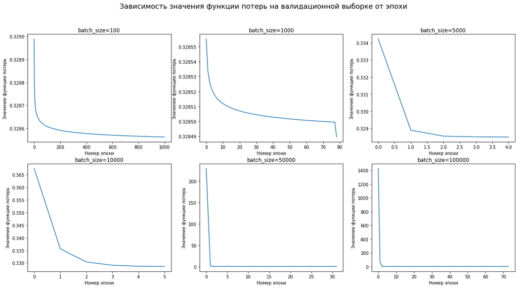

```python
# зависимость функции потерь на валидационной выборке от эпохи

import matplotlib.pyplot as plt

fig, ax = plt.subplots(nrows=2, ncols=int(len(results_batch_size)/2), figsize=(20, 10))
fig.suptitle('Зависимость значения функции потерь на валидационной выборке от эпохи', fontsize=16)
i=0
for row in ax:
    for col in row:
        col.plot(np.arange(len(results_batch_size[i]['func_val'])), results_batch_size[i]['func_val'])
        col.set_title('batch_size=%s'%batch_size_[i])
        col.set_xlabel('Номер эпохи')
        col.set_ylabel('Значение функции потерь')
        i+=1

plt.subplots_adjust()

plt.show()
```

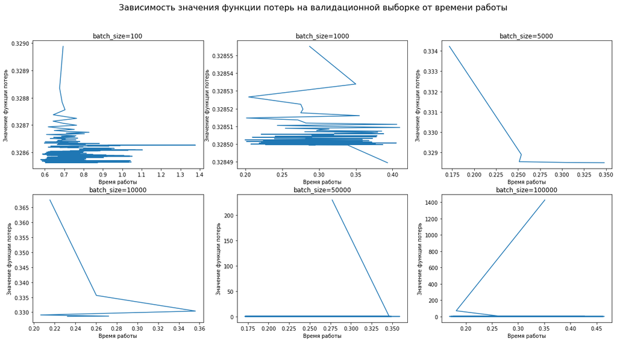

```python
# зависимость функции потерь на валидационной выборке от времени работы

import matplotlib.pyplot as plt

fig, ax = plt.subplots(nrows=2, ncols=int(len(results_batch_size)/2), figsize=(20, 10))
fig.suptitle('Зависимость значения функции потерь на валидационной выборке от времени работы', fontsize=16)
i=0
for row in ax:
    for col in row:
        col.plot(results_batch_size[i]['time'], results_batch_size[i]['func_val'])
        col.set_title('batch_size=%s'%batch_size_[i])
        col.set_xlabel('Время работы')
        col.set_ylabel('Значение функции потерь')
        i+=1

plt.subplots_adjust()

plt.show()
```

Графики, полученные на валидационной выборке, аналогичны графикам на тренировочной, что означает что эти выборки схожи по своей структуре.

```python
from tqdm.notebook import tqdm
```

```python
# исследование поведения в зависимости от step_alpha

from sklearn.metrics import balanced_accuracy_score, accuracy_score

loss_function = BinaryLogisticLoss(l2_coef=1.0)

batch_size_0=1000

results_alpha = []
ac_alpha = []

alpha_ = [0.01, 0.05, 0.1, 0.3, 0.5, 0.7, 0.9, 1.0]

for step_alpha in tqdm(alpha_):
    model = LinearModel(loss_function=loss_function, step_alpha=step_alpha, batch_size=batch_size_0)
    history = model.fit(X=X['train'], y=y_train, trace=True, X_val=X['valid'], y_val=y_val)
    results_alpha.append(history)

    threshold = model.get_optimal_threshold(X['valid'], y_val)
    y_pred = model.predict(X['valid'], threshold)
    accu = balanced_accuracy_score(y_val, y_pred)
    ac_alpha.append(accu)
```

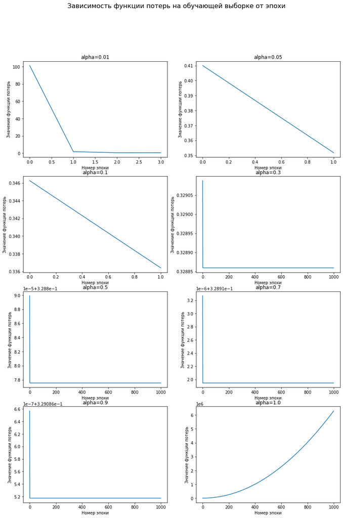

```python
# зависимость функции потерь на обучающей выборке от эпохи

import matplotlib.pyplot as plt

fig, ax = plt.subplots(nrows=4, ncols=2, figsize=(14, 20))
fig.suptitle('Зависимость функции потерь на обучающей выборке от эпохи', fontsize=16)
i=0
for row in ax:
    for col in row:
        col.plot(np.arange(len(results_alpha[i]['func'])), results_alpha[i]['func'])
        col.set_title('alpha=%s'%round(alpha_[i], 2))
        col.set_xlabel('Номер эпохи')
        col.set_ylabel('Значение функции потерь')
        i+=1

plt.subplots_adjust()

plt.show()
```

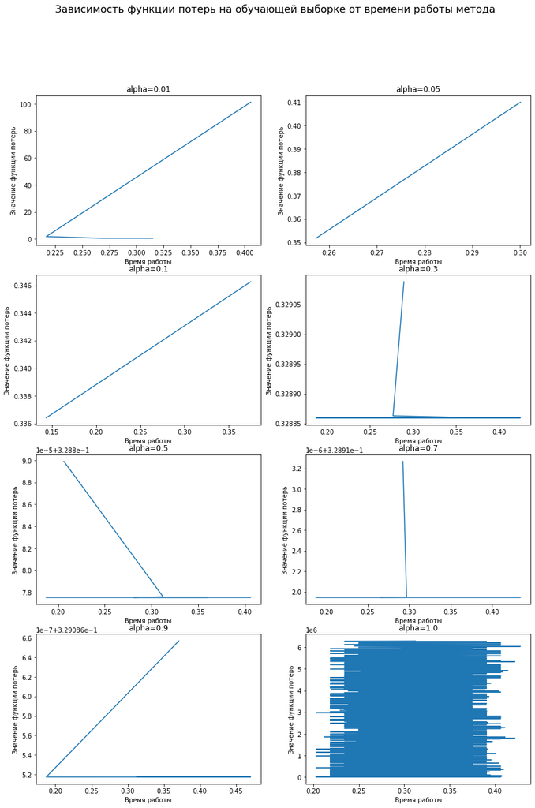

```python
# зависимость функции потерь на обучающей выборке от времени

fig, ax = plt.subplots(nrows=4, ncols=2, figsize=(14, 20))
fig.suptitle('Зависимость функции потерь на обучающей выборке от времени работы метода', fontsize=16)
i=0
for row in ax:
    for col in row:
        col.plot(results_alpha[i]['time'], results_alpha[i]['func'])
        col.set_title('alpha=%s'%round(alpha_[i], 2))
        col.set_xlabel('Время работы')
        col.set_ylabel('Значение функции потерь')
        i+=1

plt.subplots_adjust()

plt.show()
```

На графиках видна быстрая сходимость функции потерь к константному значению, близкому к нулю в случае, если параметр меньше 0.3, в остальных случаях происходит быстрый спуск на константу, при 1.0 наблюдается множество скачков ввиду расходимости.

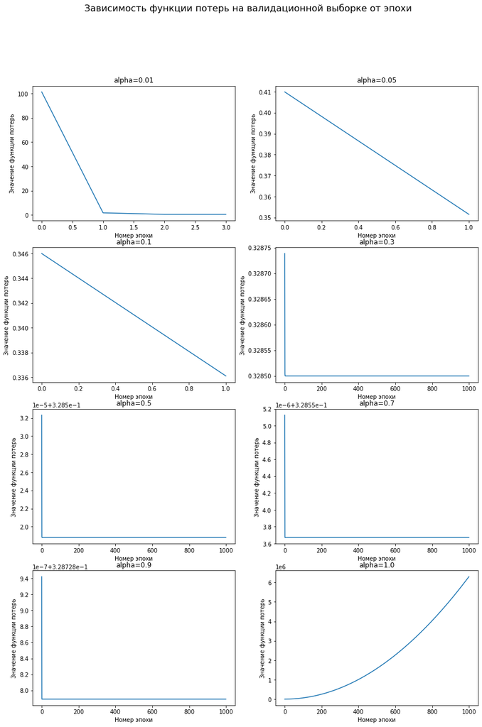

```python
# зависимость функции потерь на валидационной выборке от эпохи

import matplotlib.pyplot as plt

fig, ax = plt.subplots(nrows=4, ncols=2, figsize=(14, 20))
fig.suptitle('Зависимость функции потерь на валидационной выборке от эпохи', fontsize=16)
i=0
for row in ax:
    for col in row:
        col.plot(np.arange(len(results_alpha[i]['func_val'])), results_alpha[i]['func_val'])
        col.set_title('alpha=%s'%round(alpha_[i], 2))
        col.set_xlabel('Номер эпохи')
        col.set_ylabel('Значение функции потерь')
        i+=1

plt.subplots_adjust()

plt.show()
```

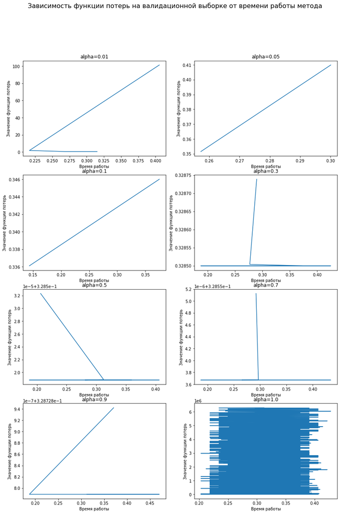

```python
# зависимость функции потерь на валидационной выборке от времени

import matplotlib.pyplot as plt

fig, ax = plt.subplots(nrows=4, ncols=2, figsize=(14, 20))
fig.suptitle('Зависимость функции потерь на валидационной выборке от времени работы метода', fontsize=16)
i=0
for row in ax:
    for col in row:
        col.plot(results_alpha[i]['time'], results_alpha[i]['func_val'])
        col.set_title('alpha=%s'%round(alpha_[i], 2))
        col.set_xlabel('Время работы')
        col.set_ylabel('Значение функции потерь')
        i+=1

plt.subplots_adjust()

plt.show()
```

Графики, полученные на валидационной выборке, аналогичны графикам на тренировочной, что означает что эти выборки схожи по своей структуре.

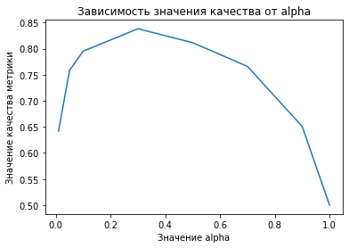

```python
# значения качества метрики

plt.plot(alpha_, ac_alpha)
plt.title('Зависимость значения качества от alpha')
plt.xlabel('Значение alpha')
plt.ylabel('Значение качества метрики')
plt.show()
```

```python
# исследование поведения в зависимости от step_beta

from sklearn.metrics import balanced_accuracy_score

loss_function = BinaryLogisticLoss(l2_coef=1.0)

results_beta = []
ac_beta = []

beta_ = np.arange(0, 1.01, 0.2)

for step_beta in tqdm(beta_):
    model = LinearModel(loss_function=loss_function, step_beta=step_beta, batch_size=batch_size_0)
    history = model.fit(X=X['train'], y=y_train, trace=True, X_val=X['valid'], y_val=y_val)
    results_beta.append(history)

    threshold = model.get_optimal_threshold(X['valid'], y_val)
    y_pred = model.predict(X['valid'], threshold)
    ac_beta.append(balanced_accuracy_score(y_val, y_pred))
```

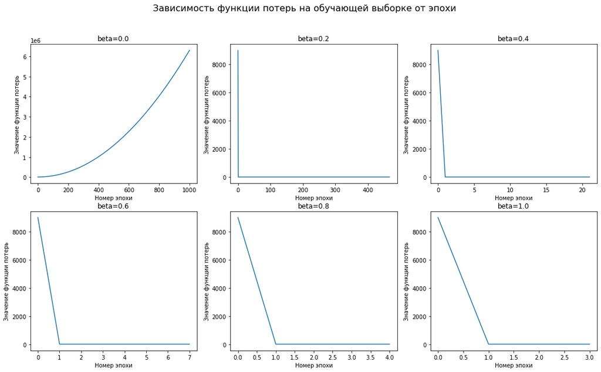

```python
# зависимость функции потерь на обучающей выборке от эпохи

import matplotlib.pyplot as plt


fig, ax = plt.subplots(nrows=2, ncols=int(len(results_beta)/2), figsize=(18, 10))
fig.suptitle('Зависимость функции потерь на обучающей выборке от эпохи', fontsize=16)
i=0
for row in ax:
    for col in row:
        col.plot(np.arange(len(results_beta[i]['func'])), results_beta[i]['func'])
        col.set_title('beta=%s'%round(beta_[i], 2))
        col.set_xlabel('Номер эпохи')
        col.set_ylabel('Значение функции потерь')
        i+=1

plt.subplots_adjust()

plt.show()
```

Как видно из графиков, при $\beta = 0$ наблюдается расходимость ввиду превращения знаменателя в единицу и отсутствия уменьшения шага, при остальных значениях функция потерь стремится к нулю.

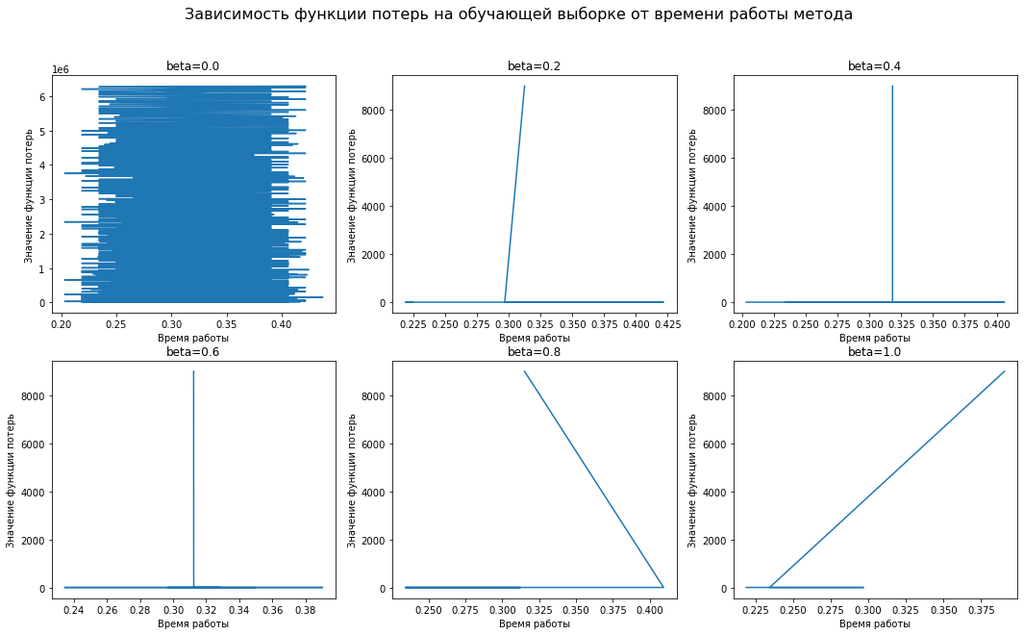

```python
# зависимость функции потерь на обучающей выборке от времени

fig, ax = plt.subplots(nrows=2, ncols=int(len(results_beta)/2), figsize=(18, 10))
fig.suptitle('Зависимость функции потерь на обучающей выборке от времени работы метода', fontsize=16)
i=0
for row in ax:
    for col in row:
        col.plot(results_beta[i]['time'], results_beta[i]['func'])
        col.set_title('beta=%s'%round(beta_[i], 2))
        col.set_xlabel('Время работы')
        col.set_ylabel('Значение функции потерь')
        i+=1

plt.subplots_adjust()

plt.show()
```

Как было сказано выше, при $\beta = 0$ наблюдается расходимость, так что на графике видно, что происходит много итераций, однако значение функци потерь значительно не уменьшается. В остальных случаях значение функции потерь быстро стремится к нулю.

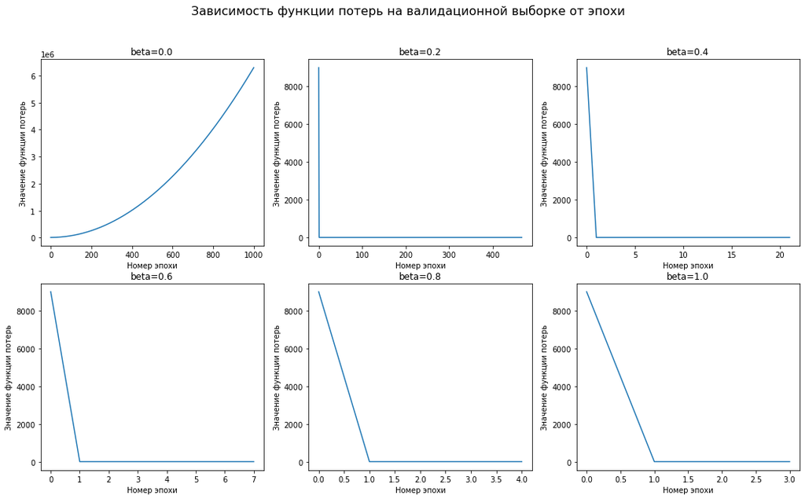

```python
# зависимость функции потерь на валидационной выборке от эпохи

import matplotlib.pyplot as plt

fig, ax = plt.subplots(nrows=2, ncols=int(len(results_beta)/2), figsize=(18, 10))
fig.suptitle('Зависимость функции потерь на валидационной выборке от эпохи', fontsize=16)
i=0
for row in ax:
    for col in row:
        col.plot(np.arange(len(results_beta[i]['func_val'])), results_beta[i]['func_val'])
        col.set_title('beta=%s'%round(beta_[i], 2))
        col.set_xlabel('Номер эпохи')
        col.set_ylabel('Значение функции потерь')
        i+=1

plt.subplots_adjust()

plt.show()
```

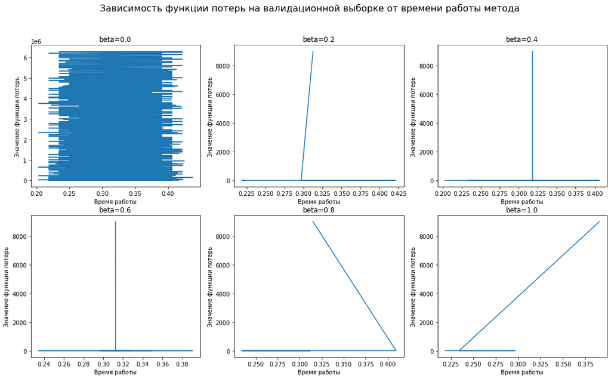

```python
# зависимость функции потерь на валидационной выборке от времени

import matplotlib.pyplot as plt

fig, ax = plt.subplots(nrows=2, ncols=int(len(results_beta)/2), figsize=(18, 10))
fig.suptitle('Зависимость функции потерь на валидационной выборке от времени работы метода', fontsize=16)
i=0
for row in ax:
    for col in row:
        col.plot(results_beta[i]['time'], results_beta[i]['func_val'])
        col.set_title('beta=%s'%round(beta_[i], 2))
        col.set_xlabel('Время работы')
        col.set_ylabel('Значение функции потерь')
        i+=1

plt.subplots_adjust()

plt.show()
```

Графики, полученные на валидационной метрике, аналогичны графикам на тренировочной, что означает что эти выборки схожи по своей структуре.

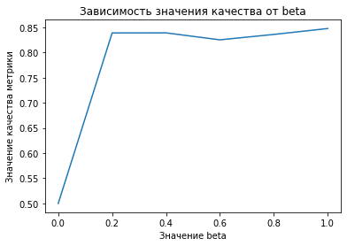

```python
# значения качества метрики

plt.plot(beta_, ac_beta)
plt.title('Зависимость значения качества от beta')
plt.xlabel('Значение beta')
plt.ylabel('Значение качества метрики')
plt.show()
```

```python
# оптимальные значения step_alpha и step_beta

max_ac_alpha = np.max(ac_alpha)
alpha_opt = list(ac_alpha).index(max_ac_alpha)
print('Оптимальное значение alpha: ', alpha_[alpha_opt])

max_ac_beta = np.max(ac_beta)
beta_opt = list(ac_beta).index(max_ac_beta)
print('Оптимальное значение beta: ', beta_[beta_opt])
```

```
Оптимальное значение alpha:  0.3
Оптимальное значение beta:  1.0
```

**Задание №6:**

Стохастический градиентный спуск обеспечивает быструю сходимость без потери значения точности метода по сравнению с полным градиентным спуском, более подробный анализ был проведен выше.

Оптимальные значения $\alpha$, полученные в полном и стохастическом градиентных спусках согласуются (в полном градиентном спуске оптимальное значение $\alpha=0.7$), так как, если вспомнить график зависимости точности от $\alpha$ при значениях от 0.3 до 0.9 наблюдалось практически плато на значениях точности.

Таким образом, на основе данного анализа возьмем метод стохастического градиентного спуска с размером batch-a: 1000, $\alpha = 0.3$, $\beta=1.0$.

**Задание №7:**

```python
# подбор коэффициента регуляризации

step_alpha = 0.3
step_beta = 1.0
batch_size = 1000

for c_coef in np.logspace(-3, 2, base=2, num=6):
    loss_function = BinaryLogisticLoss(l2_coef=c_coef)

    model = LinearModel(loss_function=loss_function, step_alpha=step_alpha, step_beta=step_beta, batch_size=batch_size)
    model.fit(X=X['train'], y=y_train, trace=False)

    threshold = model.get_optimal_threshold(X['valid'], y_val)
    y_pred = model.predict(X['valid'], threshold)
    accuracy_value = balanced_accuracy_score(y_val, y_pred)
    print(f'{c_coef:.3f}: accuracy={accuracy_value:.3f}')
```

```
0.125: accuracy=0.857
0.250: accuracy=0.836
0.500: accuracy=0.847
1.000: accuracy=0.843
2.000: accuracy=0.831
4.000: accuracy=0.661
```

Лучшее значение точности получено при значении коэффициента регуляризации $c\_coef = 0.125$. Значение точности на валидационной выборке: $0.857$

```python
# получение результатов на тестовой выборке

c_coef_opt = 0.125
loss_function = BinaryLogisticLoss(l2_coef=c_coef_opt)

model = LinearModel(loss_function=loss_function, step_alpha=step_alpha, step_beta=step_beta, batch_size=batch_size)
model.fit(X=X['train'], y=y_train, trace=False)
threshold = model.get_optimal_threshold(X['valid'], y_val)
y_pred = model.predict(X['test'], threshold)
accuracy_value = balanced_accuracy_score(y_test, y_pred)
print(f' accuracy: {accuracy_value:.3f}')
```

```
 accuracy: 0.855
```

Таким образом, итоговое значение точности на тестовой выборке: $0.855$